# Agricultural price volatility

Competing explanations

Christophe Gouel

INRAE, IFE-CEPII

# Introduction

### Objectives

- Main features of agricultural price volatility.
- Underlying competing theories.
- Role of expectations in economic dynamics.

One of the underlying questions beyond the models we will see is **Is price volatility optimal?**

**References**: Gouel (2012), Wright (2011), Wright (2014)

### Data sources

Price series: World Bank, https://www.worldbank.org/en/research/commodity-markets.

Quantities: USDA, PSD, http://www.fas.usda.gov/psdonline/.

# Stylized facts

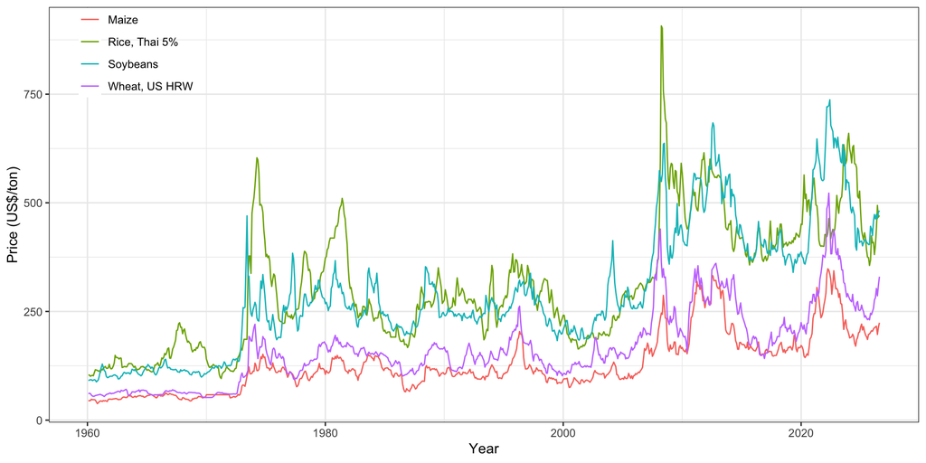

Nominal agricultural commodity prices since 1960 (source: World Bank)

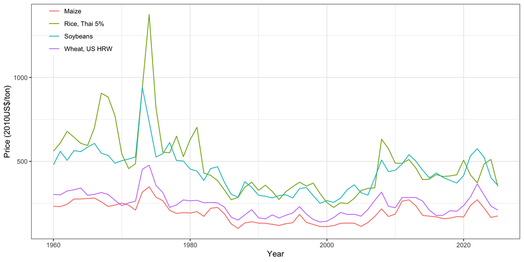

Real agricultural commodity prices since 1960 (source: World Bank)

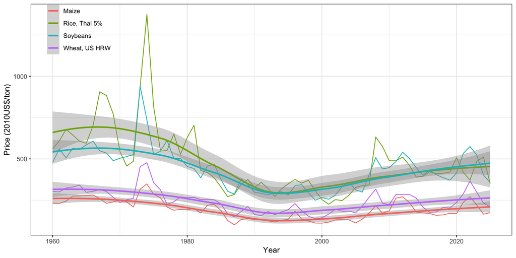

Real agricultural commodity prices since 1960 with trend (source: World Bank)

### Descriptive statistics on detrended prices

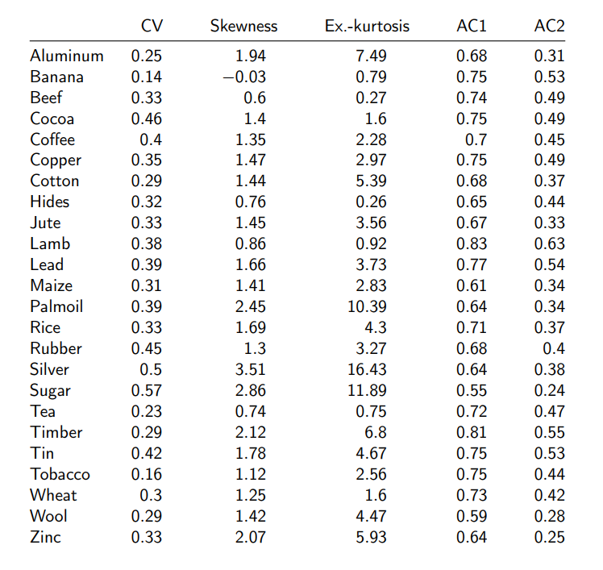

### Stylized facts

- Recent real spikes not unprecedented.
- Long-run downward trend of real prices.
- Succession of doldrums, and booms and bust periods.
- Infrequent price spikes (every 15-25 years).
- Large positive auto-correlation.
- More time is spent below the mean price than above, but positive deviations tend to be larger than negative ones (i.e., positive skewness).
- Because of demand and supply substitution possibilities, staple food commodities tend to co-move in the long-run.

### Putting dynamics into the supply-demand model

To explain movements in the price of goods, economists rely on the supply-demand model, with emphasis on

- Shocks: shifts to demand or supply
  - There are many shocks that affect commodity prices: exchange rates, inflation, input prices, … Here we focus on supply shocks both exogenous and endogenous (i.e., caused by agents’ reaction).
- Behavioral reactions: elasticities
  - Must satisfy Gregory King’s Law (small supply decrease leads to a large price increase): inelastic demand and supply functions
- Equilibrium
  - Importance of dynamics

To explain commodity price dynamics, we will start from a simple supply-demand model and add a few dynamic features that will allow it to reproduce the stylized facts.

# The Cobweb model

### Cattle cycle (Source: Ezekiel 1938)

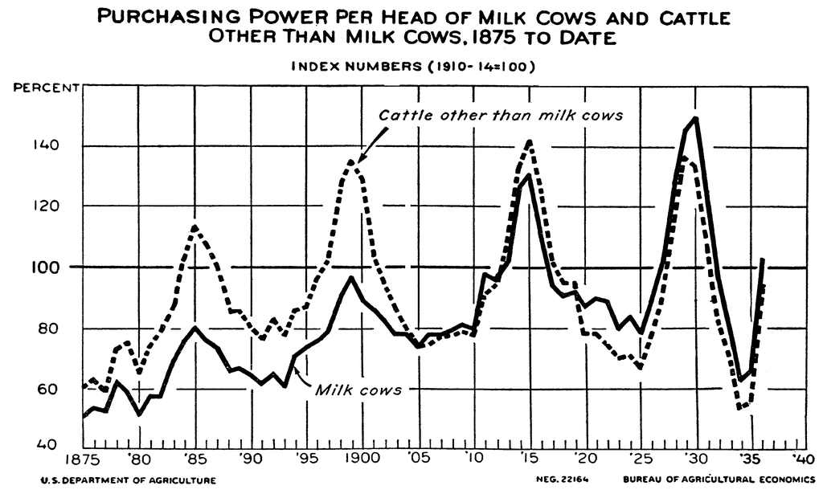

## The original Cobweb model

### Equations

From Ezekiel (1938):
$$\begin{align}
q^{D}_t & = a - b p_t & & \text{Demand} \\
q^{S}_t & = c + d \hat{p}_t + \epsilon_t & & \text{Supply} \\
q^{D}_t & = q^{S}_t & & \text{Market equilibrium} \\
\hat{p}_t & = p_{t-1} & & \text{Naive expectations}
\end{align}$$

Important innovations from the Cobweb model:

- Production is short-run inelastic;
- Production is a function of the previous period situation.

### Dynamics

Price dynamics defined by a linear dynamical equation:
$$p_{t} = \frac{a - c}{b} - \frac{d}{b}p_{t-1} - \frac{\epsilon_{t}}{b}$$

Steady-state (defined as self-replicating price equilibrium in the absence of shocks):
$$\bar p = \frac{a - c}{b + d}.$$

It gives the following solution
$$p_{t} = \underbrace{\bar{p}}_{\text{SS}} + \overbrace{\left(-\frac{d}{b}\right)^{t}\left(p_{0}-\bar{p}\right)}^{\text{Deterministic
fluctuations}} - \underbrace{\frac{1}{b}\sum_{i=0}^{t-1}\left(-\frac{d}{b}\right)^{i}\epsilon_{t-i}}_{\text{Stochastic
fluctuations}}$$

### Dynamics (without random shock)

Let’s focus on the deterministic part. We have 3 oscillatory regimes:

- Explosive if $\frac{d}{b} > 1$
- Steady oscillations if $\frac{d}{b} = 1$
- Damped if $\frac{d}{b} < 1$

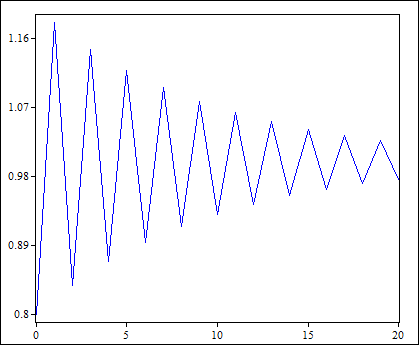

Damped

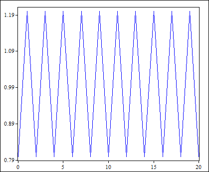

Steady

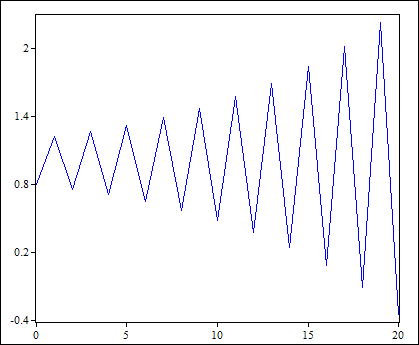

Explosive

### The role of elasticities

Demand and supply elasticities defined as
$$\begin{gathered}
e^{D}=\frac{\partial q^{D}/\partial p}{q^{D}/p}=\frac{-b}{q^{D}/p}\\
e^{S}=\frac{\partial q^{S}/\partial p}{q^{S}/p}=\frac{d}{q^{S}/p},
\end{gathered}$$

$$\Rightarrow \frac{d}{b} = -\frac{e^{S}}{e^{D}}.$$

$e^{S} > \left| e^{D} \right|$ is natural in staple food markets, which would make the explosive regime the norm.

### The cobweb diagram (Source: Ezekiel 1938)

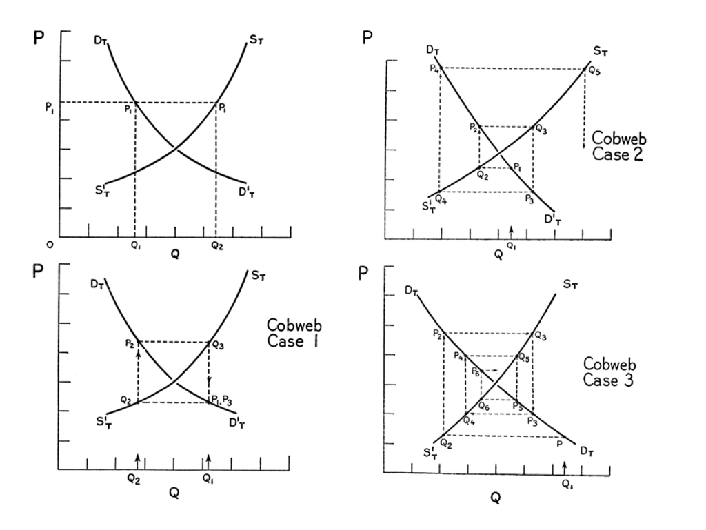

### Critics of the original Cobweb model

- Producers lose money (Buchanan 1939): how to justify the entry of more producers willing to waste money on an unprofitable business.
- Unrealistic dynamics - One never sees divergent or negative prices - Need to extend the stability range.
- Arbitrary expectations.

## Adaptive expectations

### Linear cobweb with adaptive expectations

Farmers will probably not follow immediately a sudden change in prices, and will adjust their production schedules but with a delay.

Nerlove (1958): producers revise their expectations depending on their last period forecasting errors.
$$\begin{aligned}
\hat{p}_t &= \left(1-w\right) \hat{p}_{t-1}+w p_{t-1},\\
\hat{p}_t &= \hat{p}_{t-1}+w\left(p_{t-1}-\hat{p}_{t-1}\right),
\end{aligned}$$

with $0 < w \le 1$ expectations weight factor. This scheme encompasses the naive case for $w = 1$.

It can also be expressed as
$$\hat{p}_{t} = w\sum_{i=1}^{\infty}\left( 1 - w \right)^{i-1}p_{t-i}.$$
So current expectation reflects a weighted average of all past prices, where the weights get smaller and smaller as we move further in the past.

### Dynamics with adaptive expectations

Neglecting shocks, and doing $q_{t}^{D} - q_{t}^{S} - (1 - w)(q_{t-1}^{D} - q_{t-1}^{S}) = 0$ to get rid of the $\hat{p}_{t}$, we have the linear dynamical equation
$$p_{t} = \left[ 1 - w\left( 1 + \frac{d}{b} \right) \right]p_{t-1} + w\frac{a - c}{b},$$
which has the same steady state, $\bar{p}$. Its solution:
$$p_{t} = \bar{p} + \left[ 1 - w\left( 1 + \frac{d}{b} \right) \right]^{t}\left( p_{0} - \bar{p} \right).$$

Stability condition:
$$\left| 1 - w\left( 1 + \frac{d}{b} \right) \right| < 1,$$
which gives
$$-1 < \frac{d}{b} < \frac{2}{w} - 1$$

### Limits on $w$

For stability, the limits for the expectations weight factor is
$$w < \bar{w} = \frac{2}{1 + d/b}.$$

**Example:**

| $d/b$ | 1 | 2 | 3 |
| --- | --- | --- | --- |
| $\bar{w}$ | 1 | 2/3 | 1/2 |

The higher the ratio of supply elasticity over demand elasticity, the more backward looking expectations need to be.

## Conclusion on Cobweb models

The Cobweb was important to introduce the issues that can arise when agents have to take their decisions based on expectations.

However,

- This type of models suffers from important theoretical shortcomings
  - Systematic forecasting error.
  - Producers make losses.
  - Policy analysis is problematic in these models because agents take a lot of time to adjust their expectations to the new policy environment (not robust to Lucas critique).
- They do not fit the data:
  - Fluctuations symmetric between low and high prices.
  - For $w > 1/\left( 1 + d/b \right)$, serial autocorrelation is negative, contrary to observations.
- For numerical illustration of the cobweb model see [QuantEcon](https://intro.quantecon.org/cobweb.html).

# Models with rational expectations

## Muth’s model

### Cobweb models — The rational expectations critic

In Cobweb models the main dynamic behavior derives from systematic forecasting errors occurring in a rather simple model. Muth (1961) uses the cobweb model as an illustration of the interests of rational expectations. These systematic errors imply that producers are wasting scarce information. He advocates that expectations should be consistent with economic theory, which means that agents should base their decisions on the information available at
$$\begin{aligned}
\hat{p}_t &= \mathrm{E}\left[p_{t}|I_{t-1}\right],\\
&= \mathrm{E}_{t-1}\left[p_{t}\right],
\end{aligned}$$

where $\mathrm{E}_{t-1}$ is the expectations operator accounting for information available at time $t - 1$ ($I_{t-1}$).

### The simple rational expectations model

Very similar to the cobweb model:
$$\begin{aligned}
q^{D}_t & = a-b p_t & & \text{Demand} \\
q^{S}_t & = c+d \hat{p}_t+\epsilon_t & & \text{Supply} \\
q^{D}_t & = q^{S}_t & & \text{Market equilibrium} \\
\hat{p}_t & = \mathrm{E}_{t-1}\left(p_{t}\right) & &
\text{Rational expectations expectations}
\end{aligned}$$

To solve it, write market clearing:
$$a - b p_t = c + d \mathrm{E}_{t-1}\left( p_{t} \right) + \epsilon_t,$$
and apply expectations on it
$$\mathrm{E}_{t-1}\left[ a - b p_t \right] = \mathrm{E}_{t-1}\left[ c + d \mathrm{E}_{t-1}\left( p_{t} \right) + \epsilon_t \right],$$

So expected price is (if we assume $\mathrm{E}_{t-1}\left[ \epsilon_{t} \right] = 0$)
$$\mathrm{E}_{t-1}\left( p_t \right) = \frac{a - c}{b + d} = \bar{p}.$$

### Dynamics under rational expectations

There is no more endogenous dynamics. All instability comes from real shocks.

Producers always plan their production according to the steady-state price.

#### Does it fit the data?

Since there are no endogenous dynamics, to generate an high positive serial autocorrelation in price, we would need serially correlated production shocks.

### Production shocks

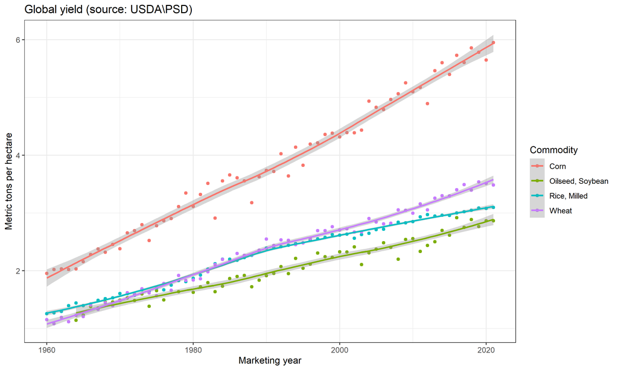

### Conclusion on the simple rational expectations model

- The simple rational expectations model answers the theoretical criticisms made to Cobweb models:
  - Agents use all available information.
  - No room for divergent behavior.
- However, **it cannot fit price data** without relying on an unrealistic distribution for yield.
- **Impacts?**
  - Neglected for long (until the 1970s and early 1980s: *the rational expectations revolution in macroeconomics*).
  - Have not convinced all Cobweb followers (the divide still exists in policy debates, but Cobweb is out of fashion).
- Need to introduce a mechanism that could generate high positive autocorrelation in the data: **Storage**

## The competitive storage model

### Competitive storage — A bit of history

That storage should matter for agricultural price dynamics is not a new idea. Physiocrats economists in the $18^{th}$ century advocate for the deregulation of grain markets in Europe considering that private storage and free trade would do better for price stability than public intervention.

> Laissez faire les hommes, laissez passer les marchandises

How to formalise this idea:

- Muth (1961) introduces also inventory speculation and shows its effect under rational expectations. However, it cheats by allowing for negative storage.
- The problem was treated previously in its full generality by Gustafson (1958).
- No more developed before the early 1980s because of computational problems.

### Behavior of private storers/speculators

We assume that storers:

- act competitively (they are price takers),
- have rational expectations.

Storing the quantity $I_{t}$ from period $t$ to period $t + 1$ entails

- a storage physical cost $k I_{t}$,
- a purchase cost $p_{t} I_{t}$,
- an opportunity cost, and
- some deterioration: a share $\delta$ of the commodity deteriorates during storage.

The benefits valued in period $t$ are $p_{t+1} I_{t} \cdot \left( 1 - \delta \right)/\left( 1 + r \right)$, where $r$ is the interest rate. The profit expected by the storer is
$$\mathrm{E}_{t}\left( \Pi_{t+1} \right) = \left[ \frac{1 - \delta}{1 + r} \mathrm{E}_{t}\left( p_{t+1} \right) - k - p_{t} \right] I_{t}$$

### Intertemporal arbitrage

Maximization of the previous equation gives, when accounting for the non-negativity on storage:
$$\begin{align}
I_{t} > 0 & \text{ if } \frac{1 - \delta}{1 + r} \mathrm{E}_{t}\left( p_{t+1} \right) = k + p_{t}, \\
I_{t} = 0 & \text{ if } \frac{1 - \delta}{1 + r} \mathrm{E}_{t}\left( p_{t+1} \right) < k + p_{t},
\end{align}$$
which is also a zero-profit condition (in expectations).

Non-negativity constraint $\Leftrightarrow$ Impossibility to borrow grain from the future.

This is a situation of a stabilizing speculation, the storerbuys when prices are low and when he rationally expects that they will be higher later.

### Competitive storage — The model

$$\begin{aligned}
&q^{D}_t = a-b p_t & & \text{Consumption}\\
&q^{S}_{t} = c+d \hat{p}_{t}+\epsilon_{t}
& &\text{Production}\\
&q^{D}_t =q^{S}_{t}+\left(1-\delta\right)I_{t-1}-I_{t} & & \text{Market equilibrium}\\
&\hat{p}_t = \mathrm{E}_{t-1}\left[p_{t}\right]
& & \text{Rational expectations}\\
&p_{t}+k-\frac{1-\delta}{1+r} \hat{p}_{t+1} \geq 0
\text{ }, =0, \text{ if } I_{t}>0 & & \text{Storage arbitrage}
\end{aligned}$$

### Competitive storage — Solving the model

The rational expectations equations $\hat{p}_t = \mathop{\mathrm{E}}_{t-1}\left[ p_{t} \right]$ is not a traditional algebraic equation. It means that agents do not make systematic forecast error, they build their expectations on all the information available.

This is not very helpful to solve the model.

Usual strategy in linear rational expectations models: guess a solution and find its parameter by solving the model. Here, it is not possible, the solution is not a simple function.

### Behavior under competitive storage

#### Definition of the state of the system

To define the behavior in one period, there are 2 pre-determined variables: $q^{S}_{t}$ and $I_{t-1}$. They can be summed together in one, availability:
$$A_{t} = q^{S}_{t} + \left( 1 - \delta \right)I_{t-1}.$$

$\Rightarrow$ What matters is not the size of the harvest or the quantity stored, but the sum of the two.

So market clearing is $q^{D}_{t} + I_{t} = A_{t}.$

We have 2 cases:

- $I_{t} = 0$, we have $q^{D}_{t} = A_{t}$, so $p_{t} = \left( q^{D} \right)^{-1}\left( A_{t} \right)$.
- $I_{t} > 0$, $p_{t} = \frac{1 - \delta}{1 + r} \mathrm{E}_{t}\left( p_{t+1} \right) - k$

### Price behavior

$$p_{t} = \max\left[ \left( q^{D} \right)^{-1}\left( A_{t} \right),\frac{1 - \delta}{1 + r} \mathrm{E}_{t}\left( p_{t+1} \right) - k \right]$$

2 regimes for prices:

- No storage: price corresponds to final demand (very inelastic).
- Positive storage: intertemporal arbitrage for price, price determined by demand for storage and so by price expectations.

### Your analysis of market behavior under competitive storage

https://christophe-gouel.shinyapps.io/Storage-model/

### Price behavior under competitive storage

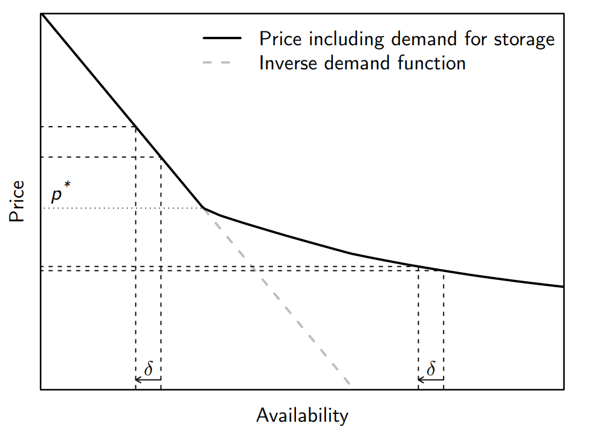

### Competitive storage — Market behaviour

- Storage tends to stabilise the price but will skew it.
  - Low prices will be less frequent because storers buy at low prices, while high prices cannot be well diminished, because when stocks are too low, their effect is limited.
- Competitive storage can never lead to perfect stabilisation.
  - For storers to participate in the market, they must cover their cost, what they do thanks to price variability. So in a world without variability, there is no storage.

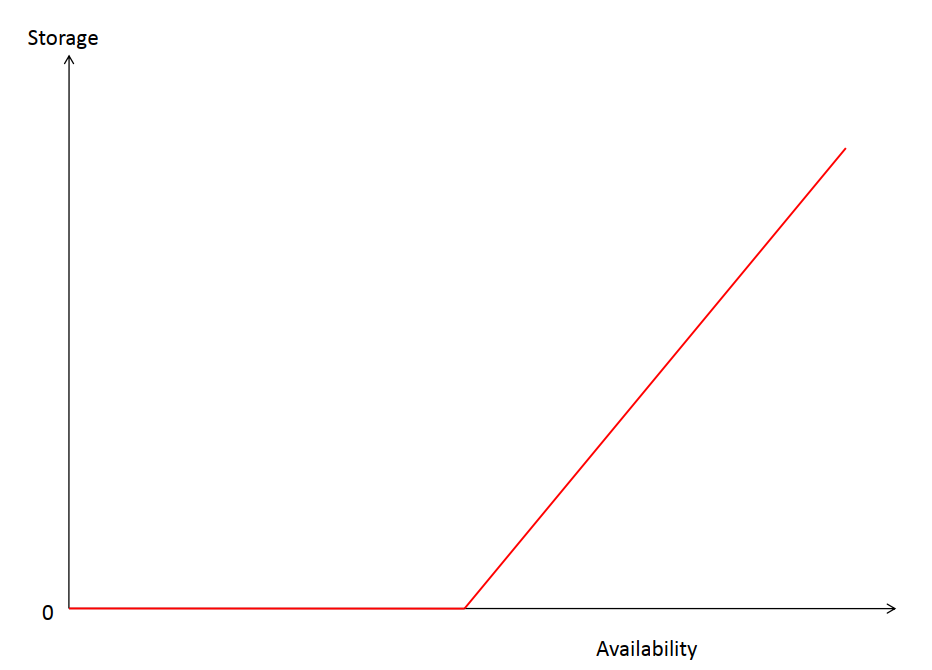

### Illustrations of the role of storage in commodity markets

Without storage, market clearing would imply supply equal demand, $q^{D} = q^{S}$, and so volatility of supply equal volatility of demand.

**Is it so?**

### Volatility of consumption

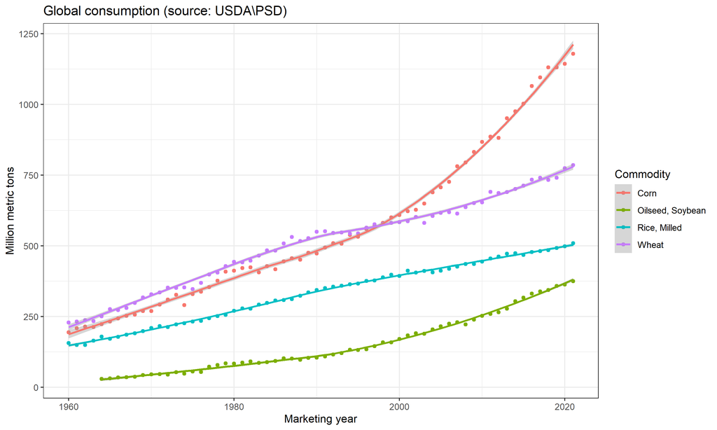

### Volatility of production

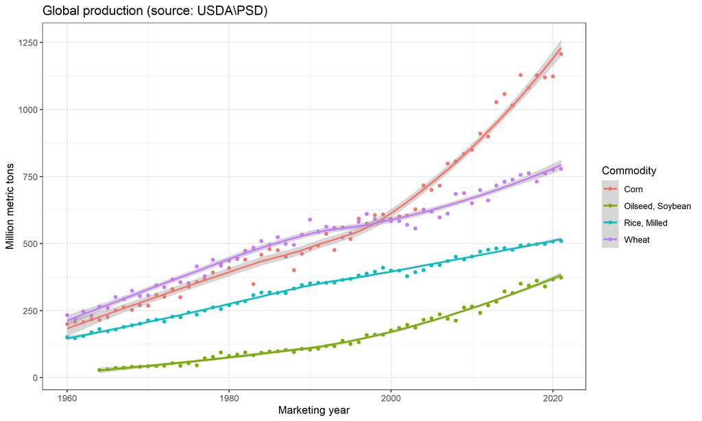

# Using theory to explain grain market behavior

### Link production, storage, and price

$\Rightarrow$ Price spikes should occur only if stocks are minimal.

### Calories from major grains (maize, rice, soybeans, and wheat)

#### Price & quantities

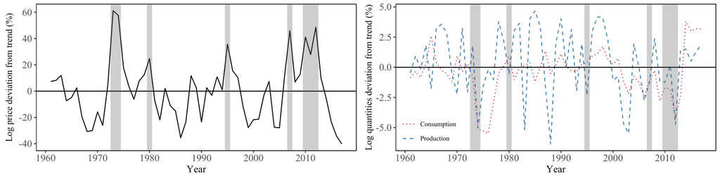

### Stocks of cereals

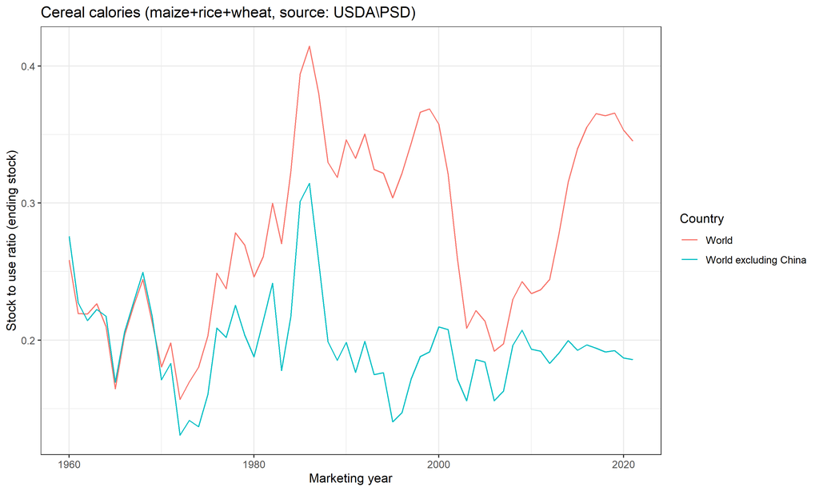

### Stocks of wheat

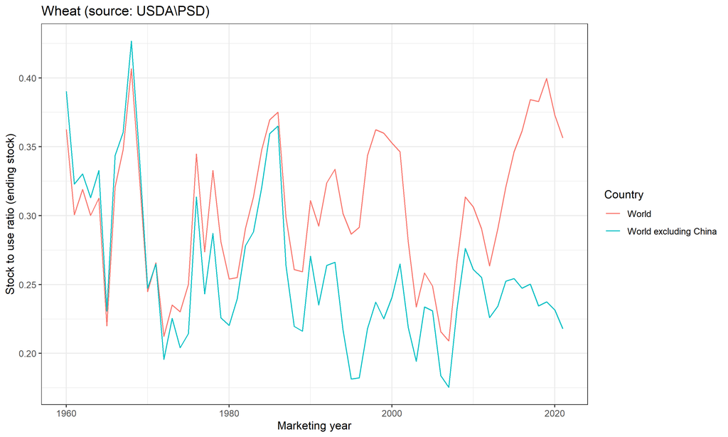

### Stocks of maize

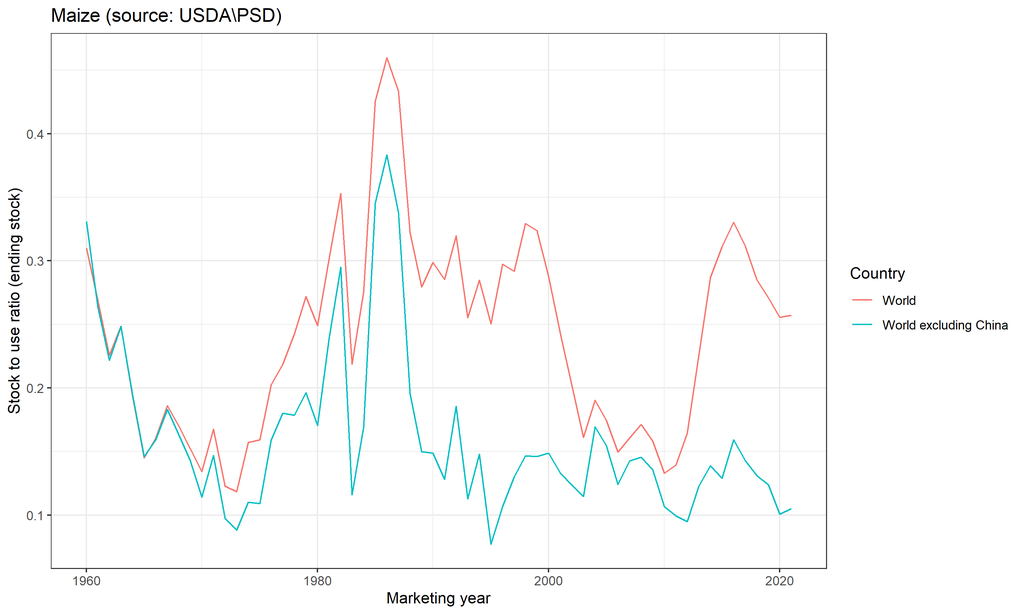

### Grain market behavior since 2005

Since 2005, it seems that there have been cereals price spikes despite stocks not always being at very low levels. Is it not in contradiction with the theory of storage?

Not if we slightly extend the model.

Consider a situation with two types of shocks:

- Transitory shocks;
- Permanent shocks.

Storage is good at smoothing transitory shocks, but not permanent shocks, and permanent shocks could reverse the link between price and stock levels.

### The effect of biofuel policies

- US
  - In the early 2000s, the MTBE was banned as a gasoline “oxygenator” in many US states and was substituted by Ethanol, produced from maize.
  - The 2005 Energy Policy Act introduced biofuels mandates as a policy instrument.
  - In 2007 the Energy Security and Independence Act increased the biofuels mandate.
  - Currently one-third of US maize production is used for biofuels.
- EU
  - A 2003 European Union directive set biofuels targets of 2% of transport fuels for 2005 rising to 5.75% by 2010. Mostly implemented through tax incentives.
  - In 2009, as part of a climate and energy policy package there was a shift to European Union use of mandates that included a 20% share of renewables in total energy consumption and a 10% share of biofuels in gasoline and diesel.

There policies are a permanent upward shock to demand.

Since it takes time for production to match the increased demand, a period of relative scarcity was to be expected. In this situation, it does not make sense to sell stocks when price increase since they are likely to increase further, because the shock is permanent.

This would not be the case with a transitory shock. If there is a bad harvest this year, there is no reason to expect a bad harvest next year and it is more profitable to sell stocks immediately.

### Stockouts?

Theory predicts that prices should spike when stocks are equal to 0. But they are never equal to zero at the end of the season.

Why?

There are many reasons other than speculation for holding stocks:

- Demand of precaution.
- Demand of transaction.
- Pipeline stocks.

# Roles of various expectations types in economics

### Public intervention

Decide which theory best represents agricultural market is critical because they lead to perfectly opposite conclusions regarding public intervention:

#### Cobweb

- The price path in cobweb-like models is socially suboptimal because farmers make decisions not grounded on the true expected variable but on backward looking information. Hence, they do not allocate their production in relation with the expected scarcity.
- Theory that emphasizes that agricultural markets are fundamentally unstable if left to themselves and should be publicly regulated.

#### Storage

There is no market imperfection, quantities are allocated by taking into account current and future scarcities. The path is optimal, no public intervention is required.

### What is the best model?

- Storage is essential to account for stylized facts of commodity markets: price autocorrelation and consumption less volatile than production.
- And it would be difficult to make sense of storage without good expectations.
- So **the basic version of the cobweb model is clearly rejected in favor of the rational expectations storage model.**
- However, behaviors following cobweb theory are often discussed for a different time-scale. In the medium run, if agents take their investment decisions on current prices, this could lead to long cycles in commodity prices. Following booms investments increase, increasing long-run production, depressing prices for a long-time, which decrease investment, leading to a new cycle.
- But such a theory is observationally equivalent to a credit constraint theory of investment where investment increases in booms because liquidity is available. $\Rightarrow$ Not the same public interventions.

### A debate not restricted to commodity prices

- The issue of backward looking expectations versus rational expectations was not limited to commodity pricing models: important also in macroeconomics.
- Macroeconomic models before the 1980s relied on backward looking expectations. Now macroeconomic research uses DSGE (Dynamic Stochastic General Equilibrium), but the previous generation of models is still in use in many central banks and finance ministries.
- Similarly, Cobweb models are no longer used for research on commodity prices, but they are still in use for applied models (e.g., AgLing/Cosimo model at OECD/FAO).

Why are cobweb models still used?

- Cobweb models are much easier to solve: simple dynamical equations. While rational expectations models may be very difficult to solve (today, it is difficult to solve the storage model with more than 3 commodities or 3 countries).
- Long lag between frontier research and applied works.
- Can serve an ideological purpose: with backward looking expectations dynamics is (severely) suboptimal, so large welfare gains from public intervention.

### Rational expectations are different from perfect foresight

- It is a common confusion to think that agents with rational expectations have perfect foresight.
- True only in a deterministic setup.
- Agents make the best use of information, but cannot foresight the realization of stochastic variables.

### Modern research on expectations

Even if rational expectations have permitted important development in economics, they are not without defaults:

- They assume agents to understand the economic system in which they live and to know the underlying parameters.
- They assume that agents pay attention to all changes in state variables.

This is assuming a lot.

### Modern alternatives to rational expectations

**Learning**

Assume that agents do not know the parameters of the model and that they learn them based on past realizations. They also form their expectations based on this evolving guess of parameters values.

**Rational inattention**

Even if agents are fully rational, they have a limited attention span and allocate it to its best use $\Rightarrow$ they will rationally miss some information, which will affect their behavior.

**Partially observed state variables**

In many situations, agents cannot perfectly observe the state (e.g., in agricultural markets it is difficult to observe the stored quantity, it is also difficult to distinguish transitory from persistent shocks to yield), but only a signal about the state. It means that they have to filter out the information, which may make their behavior backward looking. $\Rightarrow$ Backward looking expectations can be seen as a kind of learning mechanism. However, it is optimal only in very specific cases.

**Herd behavior**

In a situation of imperfect information, where there is some private information, observing others’ behavior (which is a public information) affects your own set of information. So the sequentiality of observations is crucial: if you observe people buying extra bags of rice, you may adjust your price expectations and do the same. $\Rightarrow$ Can lead to a socially undesirable outcome.

Even if in these situations agents do not take their decisions based on rational expectations, they behave with rationality given their constraints and it is not clear whether this opens the door for public interventions, except providing timely and accurate market information.

# Intra-annual dynamics, seasonality, and news shocks

### Intra-annual dynamics

Until now, we have focused on issues of inter-annual (inter-seasonal in reality) fluctuations, but the storage model has also interesting predictions for intra-annual dynamics.

Let’s first consider a deterministic situation (Samuelson 1957).

- There is no shock, everything can be perfectly foreseen.
- Harvest occurs once a year and can be stockpiled.
- In order for the good to be stockpiled so that consumption is possible during the whole year, its price has to increase at each period to cover storage costs:
  $$p_{t} + k = \frac{p_{t+1}}{1 + r}$$
- So price is at its minimum at the harvest and at its maximum just before the harvest.

The pattern is the opposite on the gas market: regular production, but irregular consumption with a winter peak.

### Deterministic seasonal fluctuations (source: Samuelson 1957)

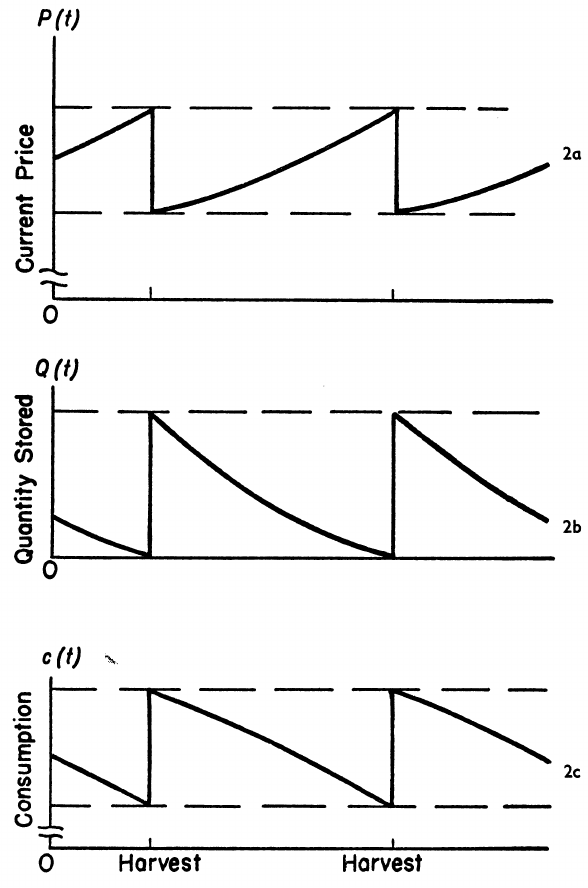

### News shocks

In reality shocks occur. And not just at harvest time.

- The realized yields that are known at the harvest are actually the outcome of a succession of biotic and climatic shocks (and also human intervention): pest invasions, too much/lack of rain, low/high temperature,…
- A priori, these shocks should not change the prevailing market equilibrium given that they do not affect any real variables. They have effects on a future real variable. They are **news shocks**.
- Because periods are connected through time by storage, news shocks will affect the prevailing market equilibrium.
  - For example, very high temperatures will indicate damage to the crops. Since the future harvest is now lower than expected before, the expected price increases. This makes storage more profitable and grains are added to the stocks until zero profit is restored. The increased demand for storage immediately increases market price.

### Seasonality and short-run volatility

In countries weakly integrated to the world market:

- Seasonal prices may vary more than annual averages
  - Prices collapse after good harvest
  - Prices spike in anticipation of poor harvest
- News shocks matter because
  - Imperfect information on upcoming harvest.
  - Import delivery lags: import decisions have to be taken without knowing what the harvest will be.

In countries, well integrated to the world market with mature marketing institutions, intra-seasonal volatility is not very important.

# The role of market information

### The role of market information in the storage model

In the rational expectations storage model, market information is key:

- Agents (in particular storers) need good information to build their expectations.
- All variables (in particular the state variable: the availability on markets) are supposed to be perfectly observable.
- If agents were to use incorrect information (like in the Cobweb models) this would result in prices not in line with the market scarcity.

Is market information really available?

### The observability of market availability

Market availability = Production + Stocks.

#### Production

- Production is not easily and cheaply observable, but good estimations are possible
  - It requires detailed surveys of producers
    - In many countries, producers have to comply because they receive a lot of public money, which may be linked in some ways to their production level.
  - Not all countries can afford good surveys. In many countries, production is the product of an estimation of planted/harvested area times estimated yields.
  - The USDA (http://apps.fas.usda.gov/psdonline/), also FAOSTAT but with some delays, provides estimations of production levels for all countries in the world.
    - They can be trusted to do it well for the US
    - But for the rest of the world, they have to rely on national statistics and on their own estimations.

### The observability of market availability

#### Stocks

- Stocks are much less observables and the quality of our information on stocks is poor
  - The USDA provides information on stock levels, but not FAOSTAT. FAOSTAT provides only information on changes in stock levels, which is not enough to estimate market availability.
  - A lot of stocks are in the hands of private firms that may be reluctant to disclose information deemed strategic.
  - For some countries, stocks are publicly owned and their level considered a secret.
    - Ex: In China, the level of stocks is secret. So the corresponding USDA numbers are a crude approximation.
    - On May 2001, the USDA released new stock estimates for China wheat, corn and rice. Total grain stocks were raised 164 million tons, a net increase of 250 percent from April 2001’s estimates. (For a comparison, the world 2001 production of wheat was 584 million tons)
    - November 2015: China corn ending stocks were raised nearly 23.8 million metric tons for 2015/16 following data revisions.
  - In a few countries, stocks are directly estimated by surveying the firms that hold stocks (e.g., US, France, Canada).
  - In most cases, stocks are a residuals from the market balance:
    - Imports and exports are usually well observed because international trade is well monitored,
    - Production is reasonably well estimated,
    - Demand (uses) is poorly estimated based on observations but also on information on population/income growth and prices,
    - Changes in stock levels are obtained as a residuals of the equation $M_{t} + Y_{t} = D_{t} + M_{t} + \Delta S_{t}$, and stock levels are recovered from a method of perpetual inventory: $S_{t} = S_{t-1} + \Delta S_{t}$. So in addition to the uncertainty created by the fact that changes in stock levels are a residual, there is uncertainty coming from the initial level of stock (which explains the reevaluation of Chinese stocks in 2001). All errors in production, trade and use are magnified for stocks.

### The observability of market availability

#### The state is not observed

In reality, the state variable of the rational expectations storage model is not directly observable and agents have to take decisions based on imperfect information. Does it open the door for public interventions? Yes and no.

- Many episodes of famine/food crises have been accredited to bad estimates of production/availability levels that led to fear and hoarding.
- If the government does not have more information than the private agents, it is unlikely to be able to improve on the situation.
- If it has more information, the best thing to do is certainly to make them publicly available.
  - There is a trade-off between the costs of collecting more market information (surveys, weather stations, …) and the benefits from reducing the uncertainty.

### Available market information

- USDA commodity forecast: issued every month. Followed by the market, after every release there is a lot of movements on futures market when investors adjust their position to the new market forecasts.
- International Grains Council (IGC)
- AMIS (Agricultural Market Information System)
  - Inter-agency platform to enhance food market transparency and encourage international policy coordination in times of crisis.
  - Should help in gathering market information from countries.
  - Established after the 2007/08 food crisis at the request of the Group of Twenty (G20) in 2011.
  - Monthly market monitor that gathers USDA, IGC, and AMIS forecast for the main crops (wheat, maize, rice, and soybeans).
- Private firms that sell their own forecasts.
  - Satelite observation + ML $\Rightarrow$ Real-time forecast of crop production

### Rice market features

- Regarding market information, the rice market is peculiar.
- Production and consumption concentrated in poor countries.
- Production by smallholder farmers, processing and trading by multiple local firms.
- Milled rice is easily storable at home in large quantities (contrary to bread).
- So market information is likely to be of poor quality making this market more prone to panic / herd behavior than other cereals such as wheat for which storage is much more concentrated.

# Conclusions

### Main points to retain

- Main features of commodity prices that a good model should satisfy:
  - A succession of doldrums, booms, and busts
  - Positive first order correlation
  - Skewness
- Importance of expectations in issues of dynamics.
- Providing timely and accurate market information is a key role for the government to ensure a well-functioning market.
- Non-negativity of storage implies that response to shocks is highly nonlinear.

### The blame game

Responsibility of each factors in recent food prices surges:

- Price of crude oil: X?
- Adverse weather: X?
- Chinese meat consumption: X?
- Biofuels policies: X?
- Speculation: X?
- Export restrictions: X?
- War: X?

### Who sank the boat?

[figure not shown]

### Who sank the boat?

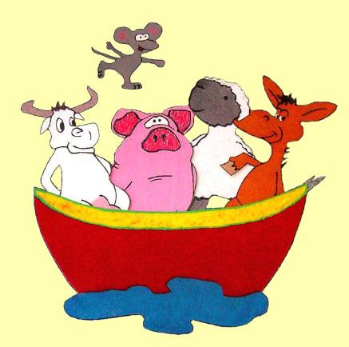

# References

Buchanan, Norman S. 1939. “A Reconsideration of the Cobweb Theorem.” *The Journal of Political Economy* 47 (1): 67–81.

Ezekiel, Mordecai. 1938. “The Cobweb Theorem.” *The Quarterly Journal of Economics* 52 (2): 255–80. https://doi.org/10.2307/1881734.

Gouel, Christophe. 2012. “Agricultural Price Instability: A Survey of Competing Explanations and Remedies.” *Journal of Economic Surveys* 26 (1): 129–56. https://doi.org/10.1111/j.1467-6419.2010.00634.x.

Gustafson, Robert L. 1958. *Carryover Levels for Grains: A Method for Determining Amounts That Are Optimal Under Specified Conditions*. Technical Bulletin No. 1178. US Dept. of Agriculture.

Muth, John F. 1961. “Rational Expectations and the Theory of Price Movements.” *Econometrica* 29 (3): 315–35. https://doi.org/10.2307/1909635.

Nerlove, Marc. 1958. “Adaptive Expectations and Cobweb Phenomena.” *The Quarterly Journal of Economics* 72 (2): 227–40. https://doi.org/10.2307/1880597.

Samuelson, Paul A. 1957. “Intertemporal Price Equilibrium: A Prologue to the Theory of Speculation.” *Weltwirtschaftliches Archiv* 79: 181–219. http://books.google.fr/books?id=XQQFn8Vk470C.

Wright, Brian D. 2011. “The Economics of Grain Price Volatility.” *Applied Economic Perspectives and Policy* 33 (1): 32–58. https://doi.org/10.1093/aepp/ppq033.

Wright, Brian D. 2014. “Global Biofuels: Key to the Puzzle of Grain Market Behavior.” *Journal of Economic Perspectives* 28 (1): 73–98. https://doi.org/10.1257/jep.28.1.73.